# 3_Plots

Henri Chung

7/21/2020

### Background

This R Markdown documents plots the results from our model workflow described in 1_model and compiled in 2_model.

##### variables

- **.taxa** - (character) what taxa category is best to aggregate OTU counts? (species0, species, genus, family, order, class, phylum)
- **response** - (character) envo_biome_2
- **.model** - (character) which model works best? (random forest, xgboost)
- **.no_components** - (numeric) for embedding methods, what length of embedding works best?
- **.method** - (character) which method of transforming otu counts performs best? (base, abundance, transformpca, transformword, word, pca)
- **id** - (character) what fold in the CV was used?
- **.macro** - (list) macro averaged performance metrics
- **.notes** - (list) output messages from model run
- **.extracts** -(list) model parameters used for that run
- **.predictions** - (table) data responses (ground truth) and model predictions
- **.null** - (table) data responses (ground truth) and model predictions from null model
- **.macro_weight** - (list) weighted macro-averaged performance metrics
- **.custom2** - (table) table of performance metrics calculated for each class individually (All vs One)
- **.null_macro_weighted** - (list) weighted macro-averaged performance metrics for null model
- **.null_custom** - (table) table of performance metrics calculated for each class individually (All vs One) for null model
- **model hyperparameters** - How robust/sensitive is a model to its hyperparameters for each method?

#### Tidy Variables

- **._metric** - performance metric (accuracy, f_meas, ppv)
- **.estimate** - numeric value for performance metric

### Metadata

##### what do our results look like?

```r
head(as_tibble(results_tune))
```

```
## # A tibble: 6 x 15
##   .taxa .response .model .no_components .method id    .macro .notes .extracts
##   <fct> <chr>     <chr>  <fct>          <fct>   <chr> <list> <list> <list>
## 1 class envobiom~ rando~ 50             abunda~ Fold~ <tibb~ <tibb~ <tibble ~
## 2 class envobiom~ rando~ 50             abunda~ Fold~ <tibb~ <tibb~ <tibble ~
## 3 class envobiom~ rando~ 50             abunda~ Fold~ <tibb~ <tibb~ <tibble ~
## 4 class envobiom~ rando~ 50             abunda~ Fold~ <tibb~ <tibb~ <tibble ~
## 5 class envobiom~ rando~ 50             abunda~ Fold~ <tibb~ <tibb~ <tibble ~
## 6 class envobiom~ rando~ 50             abunda~ Fold~ <tibb~ <tibb~ <tibble ~
## # ... with 6 more variables: .predictions <list>, .null <list>,
## #   .macro_weight <list>, .custom2 <list>, .null_macro_weighted <list>,
## #   .null_custom <list>
```

```r
colnames(results_tune)
```

```
##  [1] ".taxa"                ".response"            ".model"
##  [4] ".no_components"       ".method"              "id"
##  [7] ".macro"               ".notes"               ".extracts"
## [10] ".predictions"         ".null"                ".macro_weight"
## [13] ".custom2"             ".null_macro_weighted" ".null_custom"
```

```r
#head(as_tibble(results_validation))
```

### what is the class distribution of responses?

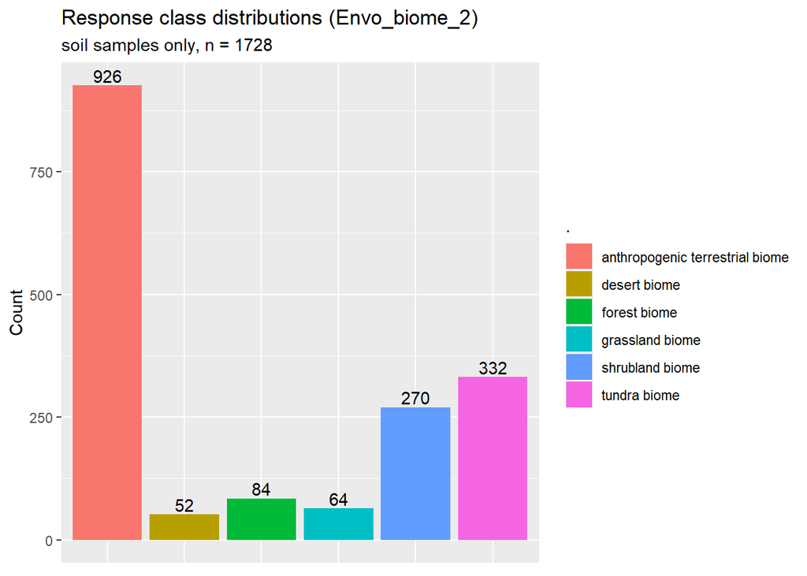

```r
#read sample data
sampledata <- read.csv("../data/emp_qiime_mapping_qc_filtered.tsv", sep = "\t") %>%
  filter(grepl("soil", Description))


#Response class distributions
p0 <- sampledata %>%
  pull(envo_biome_2) %>%
  table() %>%
  as.data.frame() %>%
  filter(Freq > 0) %>%
  ggplot(aes(x = ., y = Freq, fill = .)) + geom_bar(stat = "identity") +
  theme(axis.title.x=element_blank(),
        axis.text.x=element_blank(),
        axis.ticks.x=element_blank()) +
  geom_text(aes(label=Freq), position=position_dodge(width=0.9), vjust=-0.25) +
  labs(title = "Response class distributions (Envo_biome_2)",
       subtitle = "soil samples only, n = 1728") +
  ylab("Count")
p0
```

```r
ggsave(p0, filename = "../outputs/p0.svg", height = 6, width = 8)
```

### What is the distribution of taxa categories?

```r
soil_data <- readRDS("../data/soil_train.RDS")

p1data <-  soil_data %>%
  custom_prev_filter(0.05) %>%
  select(taxonomy) %>%
  separate(taxonomy, c("kingdom", "phylum", "class", "order", "family", "genus", "species"), sep = "; ") %>%
  mutate(species0 = paste(species, 1:nrow(.))) %>%
  apply(MARGIN = 2, function(x)length(unique(x)))
```

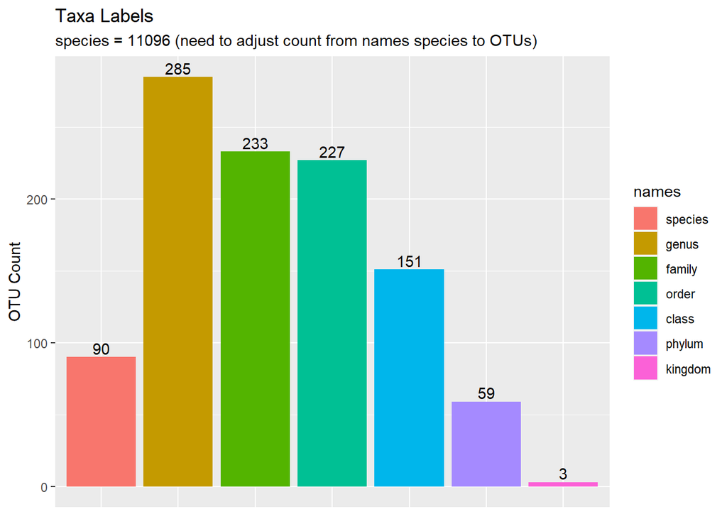

```r
p1 <- p1data %>%
  as.data.frame() %>%
  rename_(p1data = ".") %>%
  mutate(names = rownames(.)) %>%
  rename(Freq = p1data) %>%
  filter(names != "species0") %>%
  mutate(names = factor(names, levels = c("species", "genus", "family", "order", "class", "phylum", "kingdom"))) %>%
  ggplot(aes(x =names, y = Freq, fill = names)) + geom_bar(stat = "identity") +
  theme(axis.title.x=element_blank(),
        axis.text.x=element_blank(),
        axis.ticks.x=element_blank()) +
  geom_text(aes(label=Freq), position=position_dodge(width=0.9), vjust=-0.25) +
  labs(title = "Taxa Labels",
       subtitle = "species = 11096 (need to adjust count from names species to OTUs)") +
  ylab("OTU Count")
p1
```

```r
ggsave(p0, filename = "../outputs/p1.svg", height = 6, width = 8)
```

### Results

##### How well do models perform against each other using performance metrics?

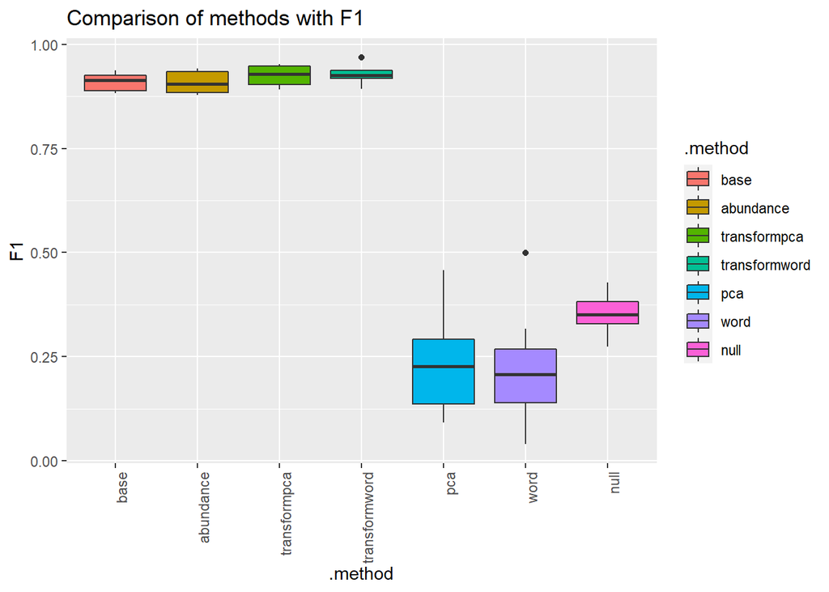

```r
p2data1 <- results_tune %>%
  select(-c(.macro, .notes, .extracts, .custom2, .null_macro_weighted, .null_custom, .null)) %>%
  filter(.taxa == "species" & .model == "randomforest") %>%
  unnest(.macro_weight) %>%
  filter(mtry %in% c(40, 41)) %>%
  select(-c( mtry))

p2data2 <- results_tune %>%
  select(-c(.macro, .notes, .extracts, .custom2, .null_macro_weighted, .null_custom, .null)) %>%
  filter(.taxa == "species" & .model == "randomforest") %>%
  unnest(.macro_weight) %>%
  filter(.method == "word" | .method == "pca") %>%
  filter(mtry %in% c(40, 41)) %>%
  select(-c( mtry))

p2data3 <- results_tune %>%
  select(-c(.macro, .notes, .extracts, .custom2, .macro_weight, .null_custom, .null)) %>%
  filter(.taxa == "species" & .model == "randomforest") %>%
  unnest(.null_macro_weighted) %>%
  mutate(.method = "null")

p2 <- bind_rows(p2data1, p2data2, p2data3) %>%
  filter(.metric == "f_meas") %>%
  filter(.no_components == "50") %>%
  mutate(.method = factor(.method, levels = c("base", "abundance", "transformpca", "transformword", "pca", "word", "null"))) %>%
  ggplot(aes(x = .method, y = .estimate, fill = .method )) +
  geom_boxplot() +
  theme(axis.text.x = element_text(angle = 90, hjust = 1)) +
  labs(title = "Comparison of methods with F1") +
  ylab("F1")
p2
```

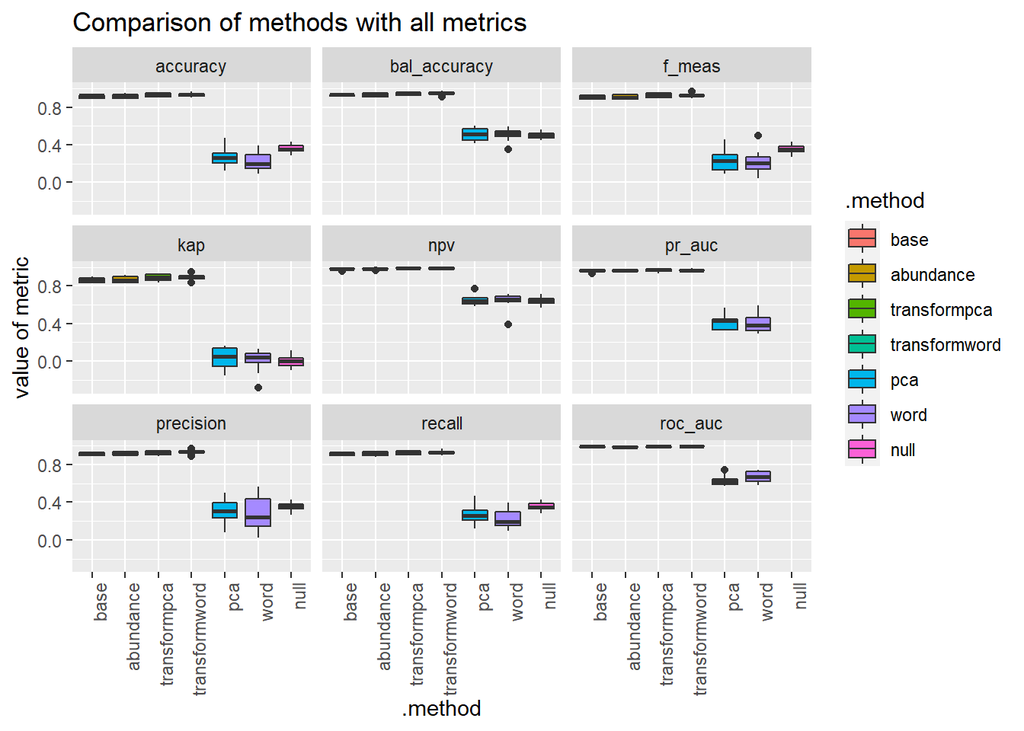

```r
ggsave(p2, filename = "../outputs/p2.svg", height = 6, width = 8)

p2b <- bind_rows(p2data1, p2data2, p2data3) %>%
  filter(.no_components == "50") %>%
  mutate(.method = factor(.method, levels = c("base", "abundance", "transformpca", "transformword", "pca", "word", "null"))) %>%
  filter(.metric %in% c("accuracy", "bal_accuracy", "f_meas", "kap", "npv", "precision", "recall", "specificity", "pr_auc", "roc_auc")) %>%
  ggplot(aes(x = .method, y = .estimate, fill = .method )) +
  geom_boxplot() +
  theme(axis.text.x = element_text(angle = 90, hjust = 1)) +
  facet_wrap(~.metric) +
  labs(title = "Comparison of methods with all metrics") +
  ylab("value of metric")
p2b
```

```r
ggsave(p2b, filename = "../outputs/p2b.svg", height = 6, width = 8)
```

### How well do models perform against each other using performance PR and ROC curves?

no PR or ROC curves for null model because there are no threshold values.

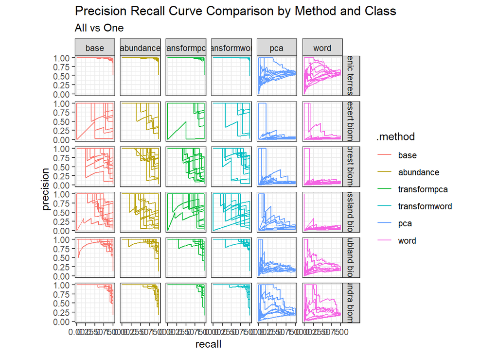

```r
p3data1 <- results_tune %>%
  select(-c(.macro, .notes, .extracts, .custom2, .null_macro_weighted, .null_custom, .null)) %>%
  filter(.taxa == "species" & .model == "randomforest" & .no_components == 50) %>%
  filter(.method != "word" & .method != "pca") %>%
  mutate(.pr_curve = map(.predictions, ~filter(., min_n == 1 & mtry %in% c(40, 41)))) %>%
  mutate(.pr_curve = map(.pr_curve, custom_pr_curve)) %>%
  unnest(.pr_curve)

p3data2 <- results_tune %>%
  select(-c(.macro, .notes, .extracts, .custom2, .null_macro_weighted, .null_custom, .null)) %>%
  filter(.taxa == "species" & .model == "randomforest" & .no_components == 50) %>%
  filter(.method == "word" | .method == "pca") %>%
  mutate(.pr_curve = map(.predictions, ~filter(., mtry %in% c(40, 41)))) %>%
  mutate(.pr_curve = map(.pr_curve, custom_pr_curve)) %>%
  unnest(.pr_curve)

p3 <- bind_rows(p3data1, p3data2) %>%
  ggplot(aes(x = recall, y = precision, group = id, color = .method)) +
  geom_path() +
  coord_equal() +
  facet_grid(.level~.method) +
  theme(axis.text.x = element_text(angle = 90, hjust = 1)) +
  theme_bw() +
  labs(title = "Precision Recall Curve Comparison by Method and Class",
       subtitle = "All vs One")
p3
```

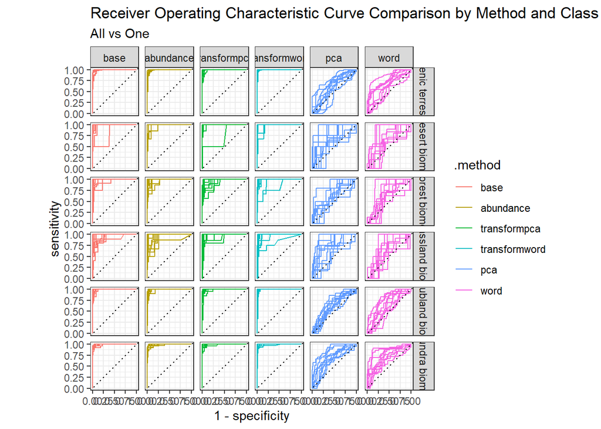

```r
ggsave(p3, filename = "../outputs/p3.svg", height = 6, width = 8)
#
p3bdata1 <- results_tune %>%
  select(-c(.macro, .notes, .extracts, .custom2, .null_macro_weighted, .null_custom, .null)) %>%
  filter(.taxa == "species" & .model == "randomforest" & .no_components == 50) %>%
  filter(.method != "word" & .method != "pca") %>%
  mutate(.roc_curve = map(.predictions, ~filter(., min_n == 1 & mtry %in% c(40, 41)))) %>%
  mutate(.roc_curve = map(.roc_curve, custom_roc_curve)) %>%
  unnest(.roc_curve)

p3bdata2 <- results_tune %>%
  select(-c(.macro, .notes, .extracts, .custom2, .null_macro_weighted, .null_custom, .null)) %>%
  filter(.taxa == "species" & .model == "randomforest" & .no_components == 50) %>%
  filter(.method == "word" | .method == "pca") %>%
  mutate(.roc_curve = map(.predictions, ~filter(., mtry %in% c(40, 41)))) %>%
  mutate(.roc_curve = map(.roc_curve, custom_roc_curve)) %>%
  unnest(.roc_curve)

p3b <- bind_rows(p3bdata1, p3bdata2) %>%
  ggplot(aes(x = 1 - specificity, y = sensitivity, group = id, color = .method)) +
  geom_path() +
  geom_abline(lty = 3) +
  coord_equal() +
  facet_grid(.level~.method) +
  theme(axis.text.x = element_text(angle = 90, hjust = 1)) +
  theme_bw() +
  labs(title = "Receiver Operating Characteristic Curve Comparison by Method and Class",
       subtitle = "All vs One")
p3b
```

```r
ggsave(p3b, filename = "../outputs/p3b.svg", height = 6, width = 8)
```

### How does the length of embeddings affect performance metrics?

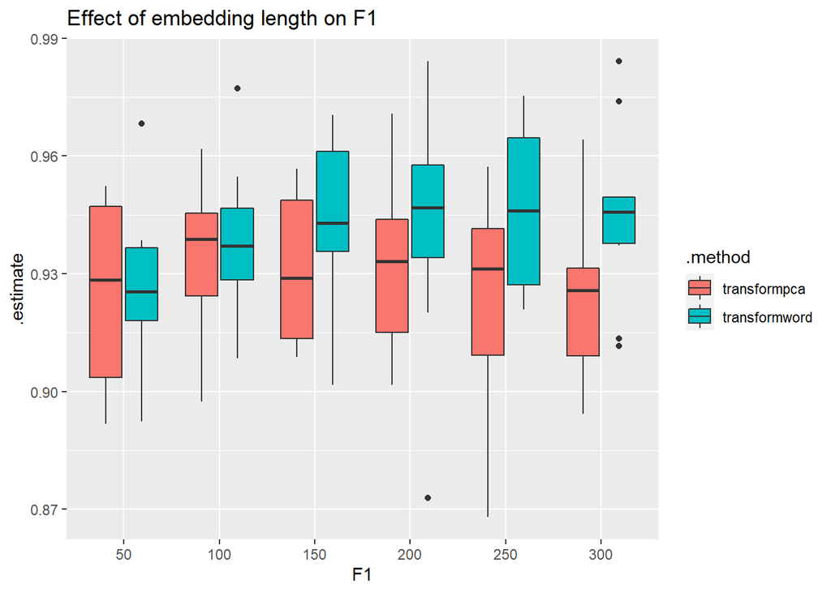

```r
p4 <-  results_tune %>%
  select(-c(.macro, .notes, .extracts, .custom2, .null_macro_weighted, .null_custom, .null)) %>%
  filter(.taxa == "species" & .model == "randomforest") %>%
  filter(.method == "transformword" | .method == "transformpca") %>%
  mutate(.macro_weight = map(.macro_weight, ~filter(., mtry %in% c(40, 41)))) %>%
  unnest(.macro_weight) %>%
  filter(.metric == "f_meas") %>%
  ggplot(aes(x = .no_components, y = .estimate, fill = .method)) +
  geom_boxplot() +
  labs(title = "Effect of embedding length on F1") +
  xlab("F1")
p4
```

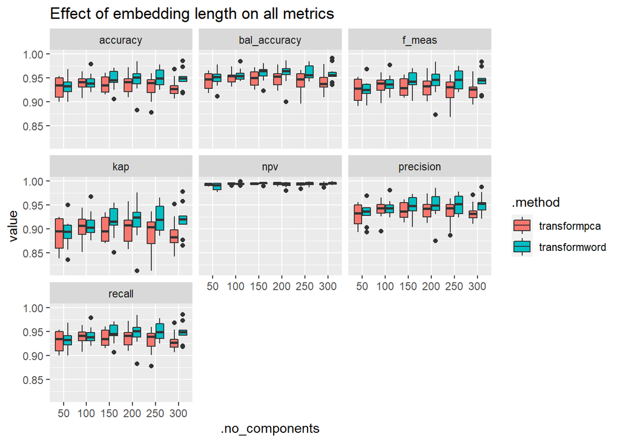

```r
ggsave(p4, filename = "../outputs/p4.svg", height = 6, width = 8)

p4b <-  results_tune %>%
  select(-c(.macro, .notes, .extracts, .custom2, .null_macro_weighted, .null_custom, .null)) %>%
  filter(.taxa == "species" & .model == "randomforest") %>%
  filter(.method == "transformword" | .method == "transformpca") %>%
  mutate(.macro_weight = map(.macro_weight, ~filter(.,mtry %in% c(40, 41)))) %>%
  unnest(.macro_weight) %>%
  filter(.metric %in% c("accuracy", "bal_accuracy", "f_meas", "kap", "npv", "precision", "recall", "specificity")) %>%
  ggplot(aes(x = .no_components, y = .estimate, fill = .method)) +
  geom_boxplot() +
  facet_wrap(~.metric) +
  labs(title = "Effect of embedding length on all metrics") +
  ylab("value")
p4b
```

```r
ggsave(p4b, filename = "../outputs/p4b.svg", height = 6, width = 8)
```

### How does the length of embedding affect PR and ROC curves?

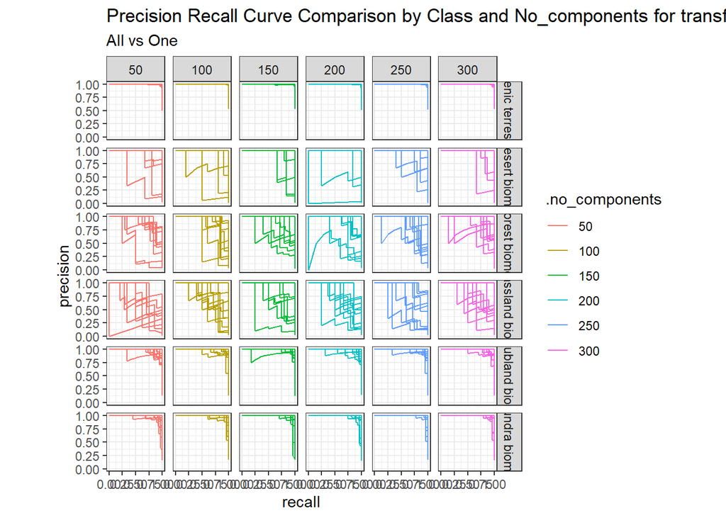

```r
p5data <- results_tune %>%
  select(-c(.macro, .notes, .extracts, .custom2, .null_macro_weighted, .null_custom, .null)) %>%
  filter(.taxa == "species" & .model == "randomforest")  %>%
  filter(.method == "transformword" | .method == "transformpca") %>%
  mutate(.pr_curve = map(.predictions, ~filter(., min_n == 1 & mtry %in% c(40, 41)))) %>%
  mutate(.pr_curve = map(.pr_curve, custom_pr_curve)) %>%
  unnest(.pr_curve)

p5 <- p5data  %>%
  filter(.method == "transformword") %>%
  ggplot(aes(x = recall, y = precision, group = id, color = .no_components)) +
  geom_path() +
  coord_equal() +
  facet_grid(.level~.no_components) +
  theme(axis.text.x = element_text(angle = 90, hjust = 1)) +
  theme_bw() +
  labs(title = "Precision Recall Curve Comparison by Class and No_components for transformword",
       subtitle = "All vs One")
p5
```

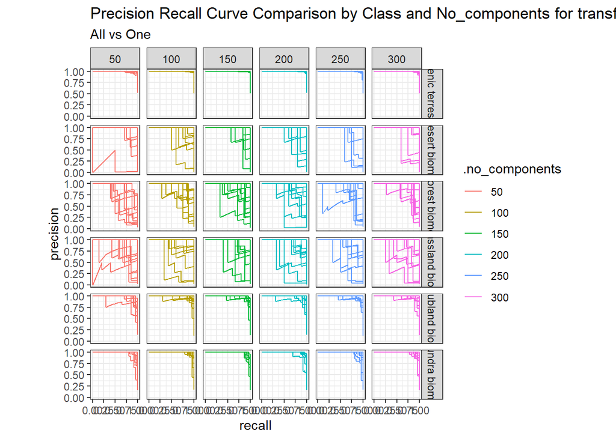

```r
ggsave(p5, filename = "../outputs/p5.svg", height = 6, width = 8)

p5b <- p5data  %>%
  filter(.method == "transformpca") %>%
  ggplot(aes(x = recall, y = precision, group = id, color = .no_components)) +
  geom_path() +
  coord_equal() +
  facet_grid(.level~.no_components) +
  theme(axis.text.x = element_text(angle = 90, hjust = 1)) +
  theme_bw() +
  labs(title = "Precision Recall Curve Comparison by Class and No_components for transformpca",
       subtitle = "All vs One")
p5b
```

```r
ggsave(p5b, filename = "../outputs/p5b.svg", height = 6, width = 8)


p6data <- results_tune %>%
  select(-c(.macro, .notes, .extracts, .custom2, .null_macro_weighted, .null_custom, .null)) %>%
  filter(.taxa == "species" & .model == "randomforest")  %>%
  filter(.method == "transformword" | .method == "transformpca") %>%
  mutate(.roc_curve = map(.predictions, ~filter(., min_n == 1 & mtry %in% c(40, 41)))) %>%
  mutate(.roc_curve = map(.roc_curve, custom_roc_curve)) %>%
  unnest(.roc_curve)


p6 <- p6data  %>%
  filter(.method == "transformword") %>%
  ggplot(aes(x = 1 - specificity, y = sensitivity, group = id, color = .no_components)) +
  geom_path() +
  geom_abline(lty = 3) +
  coord_equal() +
  facet_grid(.level~.no_components) +
  theme(axis.text.x = element_text(angle = 90, hjust = 1)) +
  theme_bw() +
  labs(title = "Receiver Operating Characteristic Curve Comparison by Class and No_components for transformword",
       subtitle = "All vs One")
p6
```

[output not shown]

```r
ggsave(p6, filename = "../outputs/p6.svg", height = 6, width = 8)

p6b <- p6data  %>%
  filter(.method == "transformword") %>%
  ggplot(aes(x = 1 - specificity, y = sensitivity, group = id, color = .no_components)) +
  geom_path() +
  geom_abline(lty = 3) +
  coord_equal() +
  facet_grid(.level~.no_components) +
  theme(axis.text.x = element_text(angle = 90, hjust = 1)) +
  theme_bw() +
  labs(title = "Receiver Operating Characteristic Curve Comparison by Class and No_components for transformword",
       subtitle = "All vs One")
p6b
```

[output not shown]

```r
ggsave(p6b, filename = "../outputs/p6b.svg", height = 6, width = 8)
```

### How does Taxa aggregation affect performance metrics?

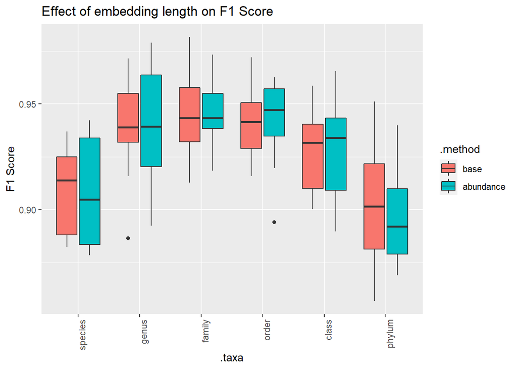

```r
p7data <- results_tune %>%
  select(-c(.macro, .notes, .extracts, .custom2, .null_macro_weighted, .null_custom, .null)) %>%
  filter(.no_components == 50) %>%
  filter(.method == "base" | .method == "abundance") %>%
  mutate(.macro_weight = map(.macro_weight, ~filter(., mtry %in% c(40, 41)))) %>%
  unnest(.macro_weight) %>%
  filter(.metric %in% c("accuracy", "bal_accuracy", "f_meas", "kap", "npv", "precision", "recall", "specificity"))
p7 <- p7data %>%
  filter(.metric == "f_meas") %>%
  ggplot(aes(x = .taxa, y = .estimate, fill = .method)) +
  geom_boxplot() +
  labs(title = "Effect of embedding length on F1 Score") +
  ylab("F1 Score") +
  theme(axis.text.x = element_text(angle = 90, hjust = 1))

p7
```

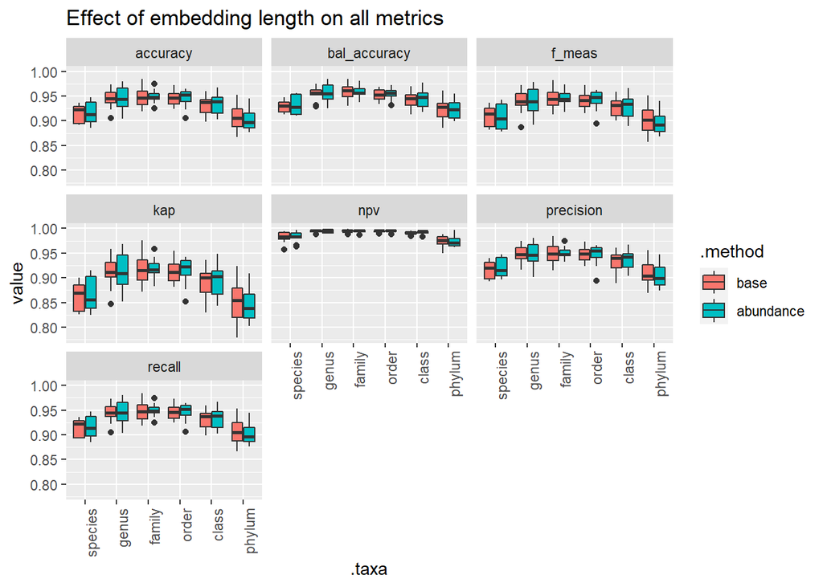

```r
ggsave(p7, filename = "../outputs/p7.svg", height = 6, width = 8)

p7b <- p7data  %>%
  ggplot(aes(x = .taxa, y = .estimate, fill = .method)) +
  geom_boxplot() +
  facet_wrap(~.metric) +
  labs(title = "Effect of embedding length on all metrics") +
  ylab("value") +
  theme(axis.text.x = element_text(angle = 90, hjust = 1))
p7b
```

```r
ggsave(p7b, filename = "../outputs/p7.svg", height = 6, width = 8)
```

### How does Taxa aggregation affect PR and ROC curves?

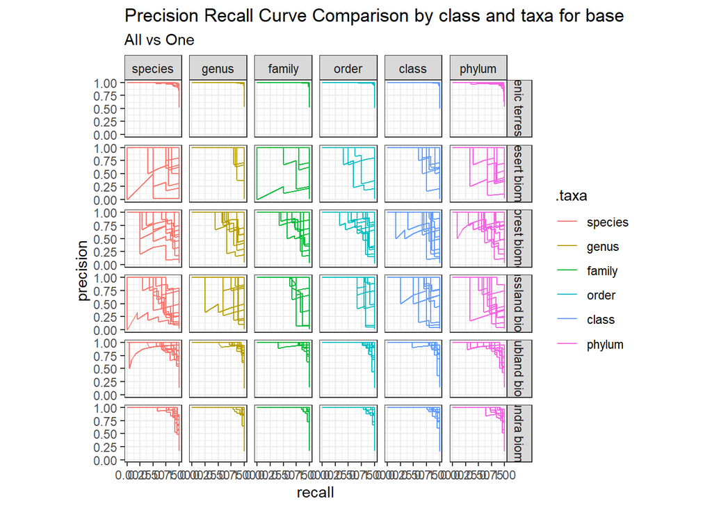

```r
p8data <- results_tune %>%
  select(-c(.macro, .notes, .extracts, .custom2, .null_macro_weighted, .null_custom, .null)) %>%
  filter(.no_components == 50) %>%
  filter(.method == "base" | .method == "abundance") %>%
  mutate(.pr_curve = map(.predictions, ~filter(., min_n == 1 & mtry %in% c(40, 41)))) %>%
  mutate(.pr_curve = map(.pr_curve, custom_pr_curve)) %>%
  unnest(.pr_curve)
p8 <- p8data  %>%
  filter(.method == "base") %>%
  ggplot(aes(x = recall, y = precision, group = id, color = .taxa)) +
  geom_path() +
  coord_equal() +
  facet_grid(.level~.taxa) +
  theme(axis.text.x = element_text(angle = 90, hjust = 1)) +
  theme_bw() +
  labs(title = "Precision Recall Curve Comparison by class and taxa for base",
       subtitle = "All vs One")
p8
```

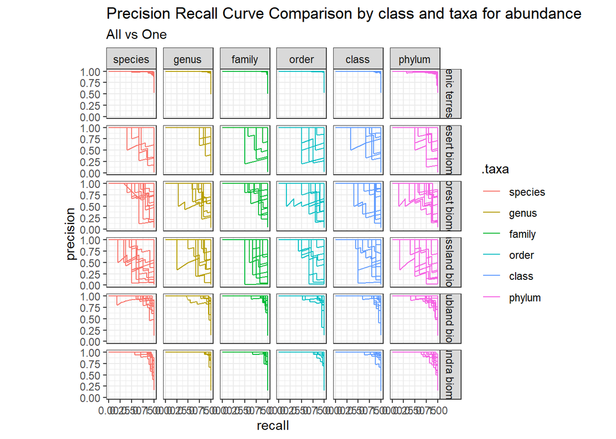

```r
ggsave(p8, filename = "../outputs/p8.svg", height = 6, width = 8)

p8b <- p8data  %>%
  filter(.method == "abundance") %>%
  ggplot(aes(x = recall, y = precision, group = id, color = .taxa)) +
  geom_path() +
  coord_equal() +
  facet_grid(.level~.taxa) +
  theme(axis.text.x = element_text(angle = 90, hjust = 1)) +
  theme_bw() +
  labs(title = "Precision Recall Curve Comparison by class and taxa for abundance",
       subtitle = "All vs One")
p8b
```

```r
ggsave(p8b, filename = "../outputs/p8n.svg", height = 6, width = 8)

p9data <-  results_tune %>%
  select(-c(.macro, .notes, .extracts, .custom2, .null_macro_weighted, .null_custom, .null)) %>%
  filter(.no_components == 50) %>%
  filter(.method == "base" | .method == "abundance") %>%
  mutate(.roc_curve = map(.predictions, ~filter(., min_n == 1 & mtry %in% c(40, 41)))) %>%
  mutate(.roc_curve = map(.roc_curve, custom_roc_curve)) %>%
  unnest(.roc_curve)


p9 <- p9data  %>%
  filter(.method == "base") %>%
  ggplot(aes(x = 1 - specificity, y = sensitivity, group = id, color = .taxa)) +
  geom_path() +
  geom_abline(lty = 3) +
  coord_equal() +
  facet_grid(.level~.taxa) +
  theme(axis.text.x = element_text(angle = 90, hjust = 1)) +
  theme_bw() +
  labs(title = "Receiver Operating Characteristic Curve Comparison by class and taxa for abundance",
       subtitle = "All vs One")
p6
```

[output not shown]

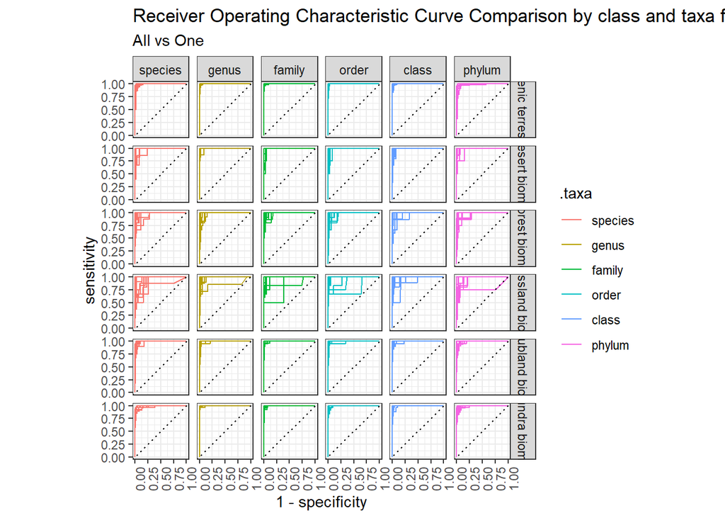

```r
ggsave(p9, filename = "../outputs/p9.svg", height = 6, width = 8)

p9b <- p9data  %>%
  filter(.method == "abundance") %>%
  ggplot(aes(x = 1 - specificity, y = sensitivity, group = id, color = .taxa)) +
  geom_path() +
  geom_abline(lty = 3) +
  coord_equal() +
  facet_grid(.level~.taxa) +
  theme_bw() +
  theme(axis.text.x = element_text(angle = 90, hjust = 1)) +
  labs(title = "Receiver Operating Characteristic Curve Comparison by class and taxa for abundance",
       subtitle = "All vs One")
p9b
```

```r
ggsave(p9b, filename = "../outputs/p9b.svg", height = 6, width = 8)
```

### How sensitive are models to hyperparameters?

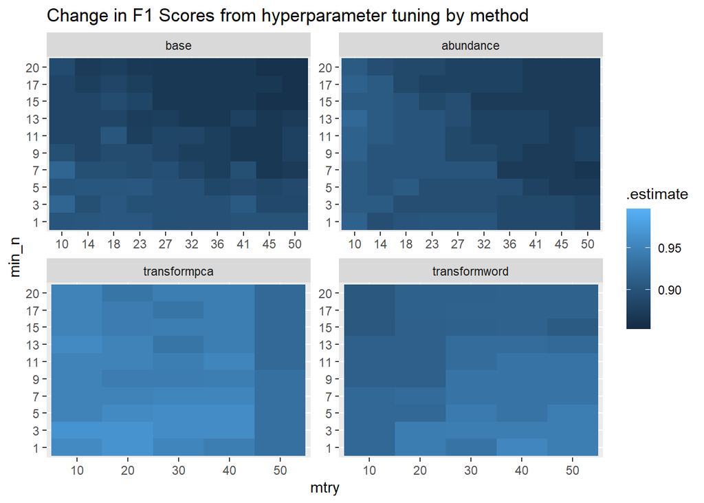

```r
p10 <- results_tune2 %>%
  select(-c(.macro, .custom2, .null_macro_weighted, .null_custom, .null)) %>%
  filter(.taxa == "species" & .model == "randomforest") %>%
  filter(.method != "pca" & .method != "word") %>%
  filter(.no_components == 50) %>%
  unnest(.macro_weight) %>%
  filter(.metric == "f_meas") %>%
  ggplot(aes(x = as.factor(mtry), y = as.factor(min_n), fill = .estimate)) +
  geom_tile() +
  facet_wrap(~.method, scales = "free") +
  labs(title = "Change in F1 Scores from hyperparameter tuning by method") +
  xlab("mtry") + ylab("min_n")
p10
```

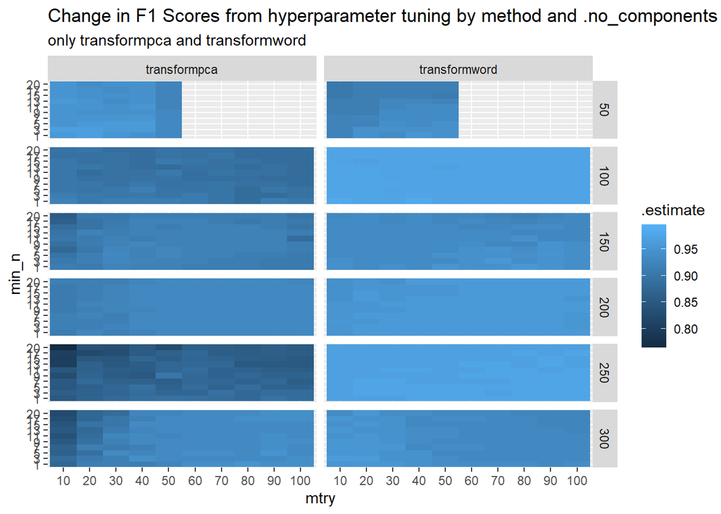

```r
ggsave(p10, filename = "../outputs/p10.svg", height = 6, width = 8)

p10b <- results_tune2 %>%
  select(-c(.macro, .custom2, .null_macro_weighted, .null_custom, .null)) %>%
  filter(.taxa == "species" & .model == "randomforest") %>%
  filter(.method == "transformword" | .method == "transformpca") %>%
  unnest(.macro_weight) %>%
  filter(.metric == "f_meas") %>%
  ggplot(aes(x = as.factor(mtry), y = as.factor(min_n), fill = .estimate)) +
  geom_tile() +
  facet_grid(.no_components~.method, scales = "free") +
  labs(title = "Change in F1 Scores from hyperparameter tuning by method and .no_components",
       subtitle = "only transformpca and transformword") +
  xlab("mtry") + ylab("min_n")
p10b
```

```r
ggsave(p10b, filename = "../outputs/p10b.svg", height = 6, width = 8)
```

### What if we repeated every previous figure but it was using xgboost instead of a randomforest model?

#### How does xgboost vary with hyperparameters?

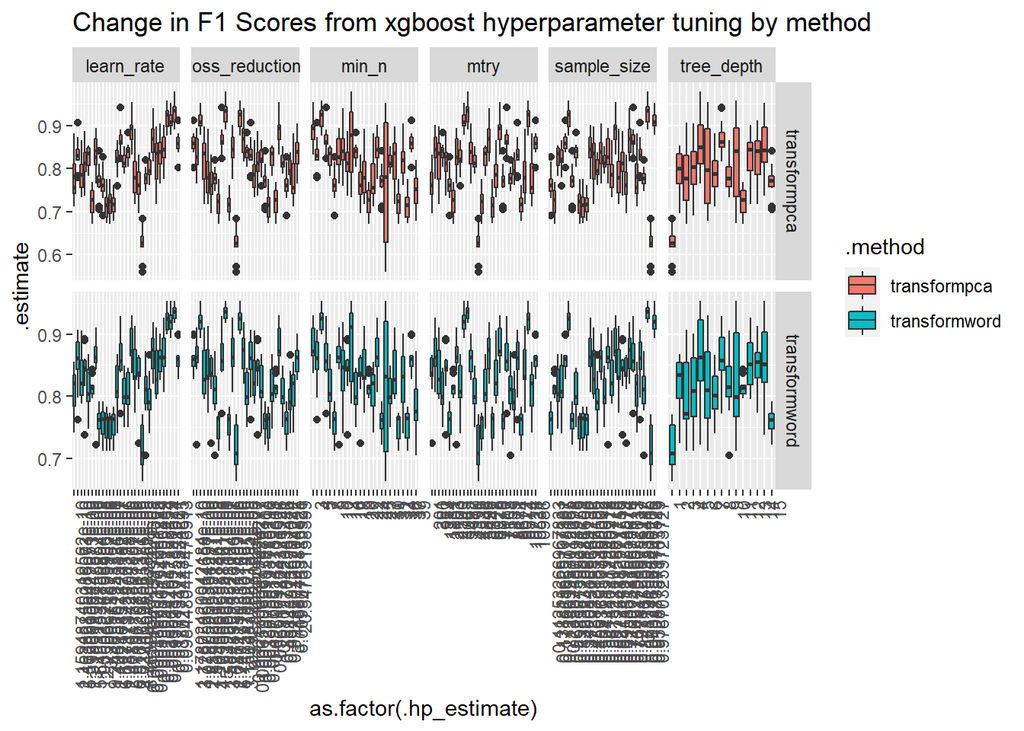

```r
x1data <- results_tune2 %>%
  select(-c(.macro, .custom2, .null_macro_weighted, .null_custom, .null)) %>%
  filter(.taxa == "species" & .model == "xgboost") %>%
  filter(.method != "pca" & .method != "word") %>%
  filter(.no_components == 50) %>%
  unnest(.macro_weight)
x1 <- x1data %>%
  filter(.metric == "f_meas") %>%
  pivot_longer(cols = c("tree_depth", "min_n", "loss_reduction", "sample_size", "mtry", "learn_rate"), names_to = ".hyperparameters", values_to = ".hp_estimate") %>%
  ggplot(aes(x = as.factor(.hp_estimate), y = .estimate, fill = .method)) +
  geom_boxplot(position = "dodge") +
  facet_grid(.method~.hyperparameters, scales = "free") +
  theme(axis.text.x = element_text(angle = 90, hjust = 1)) +
  labs(title = "Change in F1 Scores from xgboost hyperparameter tuning by method")
x1
```

```r
ggsave(x1, filename = "../outputs/x1.svg", height = 6, width = 8)
```

```r
x1b <- x1data %>%
  filter(.method == "transformword") %>%
  pivot_longer(cols = c("tree_depth", "min_n", "loss_reduction", "sample_size", "mtry", "learn_rate"), names_to = ".hyperparameters", values_to = ".hp_estimate") %>%
  ggplot(aes(x = as.factor(.hp_estimate), y = .estimate, fill = .method)) +
  geom_boxplot(position = "dodge") +
  facet_grid(.metric~.hyperparameters, scales = "free") +
  theme(axis.text.x = element_text(angle = 90, hjust = 1)) +
  labs(title = "Change in all metrics from xgboost hyperparameter tuning by method for transformword")
x1b
ggsave(x1b, filename = "../outputs/x1b.svg", height = 6, width = 8)

x1c <- x1data %>%
  filter(.method == "transformpca") %>%
  pivot_longer(cols = c("tree_depth", "min_n", "loss_reduction", "sample_size", "mtry", "learn_rate"), names_to = ".hyperparameters", values_to = ".hp_estimate") %>%
  ggplot(aes(x = as.factor(.hp_estimate), y = .estimate, fill = .method)) +
  geom_boxplot(position = "dodge") +
  facet_grid(.metric~.hyperparameters, scales = "free") +
  theme(axis.text.x = element_text(angle = 90, hjust = 1)) +
  labs(title = "Change in all metrics from xgboost hyperparameter tuning by method for transformpca")
x1c
ggsave(x1c, filename = "../outputs/x1c.svg", height = 6, width = 8)
```

[output not shown]

### Validation Set

Repeat all graphs on validation set

Messed up validation results (these are incorrect)

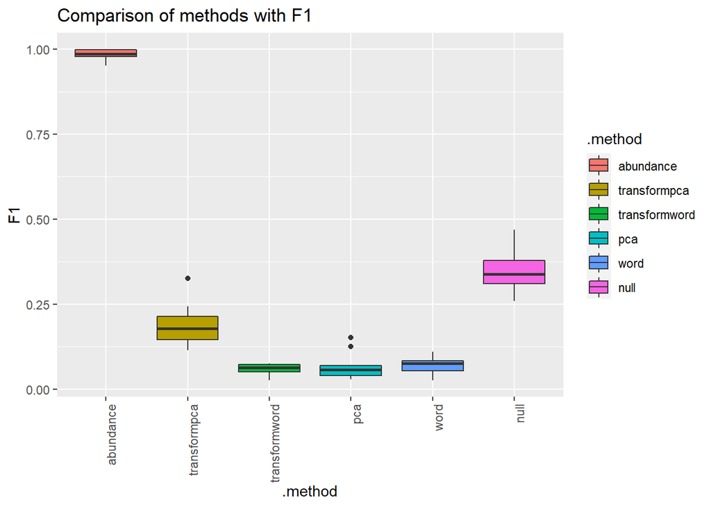

```r
results_validation <- readRDS("../data/results_validation2.RDS")
p40data1 <- results_validation %>%
  select(-c(.macro, .custom2, .null_macro_weighted, .null_custom, .null)) %>%
  filter(.taxa == "species" & .model == "randomforest") %>%
  unnest(.macro_weight)

p40data2 <- results_validation %>%
  select(-c(.macro, .custom2, .macro_weight, .null_custom, .null)) %>%
  filter(.taxa == "species" & .model == "randomforest") %>%
  unnest(.null_macro_weighted) %>%
  mutate(.method = "null")


p40 <- bind_rows(p40data1, p40data2) %>%
  filter(.metric == "f_meas") %>%
  filter(.no_components == "50") %>%
  mutate(.method = factor(.method, levels = c("base", "abundance", "transformpca", "transformword", "pca", "word", "null"))) %>%
  ggplot(aes(x = .method, y = .estimate, fill = .method )) +
  geom_boxplot() +
  theme(axis.text.x = element_text(angle = 90, hjust = 1)) +
  labs(title = "Comparison of methods with F1") +
  ylab("F1")
p40
```

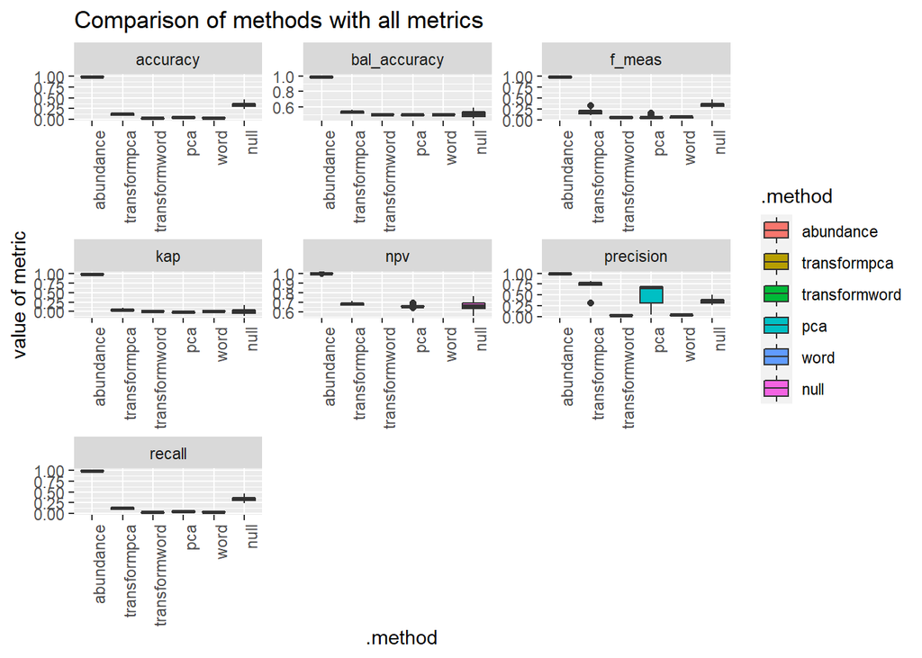

```r
ggsave(p40, filename = "../outputs/p40.svg", height = 6, width = 8)

p40b <- bind_rows(p40data1, p40data2) %>%
  filter(.no_components == "50") %>%
  mutate(.method = factor(.method, levels = c("base", "abundance", "transformpca", "transformword", "pca", "word", "null"))) %>%
  filter(.metric %in% c("accuracy", "bal_accuracy", "f_meas", "kap", "npv", "precision", "recall", "specificity")) %>%
  ggplot(aes(x = .method, y = .estimate, fill = .method )) +
  geom_boxplot() +
  theme(axis.text.x = element_text(angle = 90, hjust = 1)) +
  facet_wrap(~.metric, scales = "free") +
  labs(title = "Comparison of methods with all metrics") +
  ylab("value of metric")
p40b
```

```r
ggsave(p40b, filename = "../outputs/p40b.svg", height = 6, width = 8)
```